# 01-第一章：生命と環境

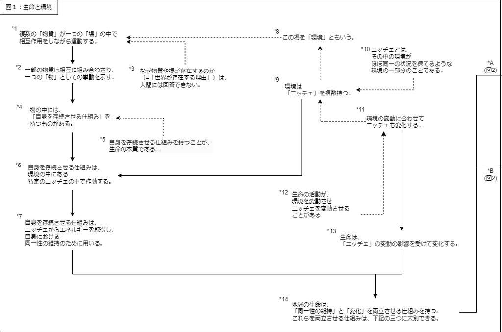

図１.png

# 議論の進め方と構図の取り方について

まずは、私たちが生きる宇宙がどのようにできているかを、物理化学的な観点からおさらいしていく。このように述べると、人によっては「宇宙や地球、あるいは生命について『理系』的な話をすることが、生き方や社会のあり方などを考えるという『文系』的な話にどう繋がるのかピンとこない」と思うかもしれないが、その疑問にはさし当たりこう答えておこう。すなわち、宇宙・地球・生命についての知見を追うことで、我々自身の生の輪郭やその将来の可能性、さらにはその限界を「大外から掘り出していく」ことが可能になるのだと。そして、この「大外から掘り出していく」スタンスによって、議論をクリアなものにすることができるのだと。

議論に宇宙・地球・生命についての知見を盛り込むことの意義はひとまず上記の通りだが、それでも議論をどこから始めるのかという点については選択の余地が残る。この点について本稿は、我々の生に直接与えられる所与から議論を始めるのではなく、先人たちの努力によって構築された客観的な世界についての説明を引き回すとことから議論を始める。それは「宇宙の中にいる我々が、宇宙を観測する」という構図を採用することで、議論をより平易にするためだ。我々の生に直接与えられる所与の観点から見た議論は、後の「04-体験とシニフィアン」以降で、「01-生命と環境」から「03-脳と自由エネルギー原理」までの議論と接続する形で行う。

# 物質・物・生命

さて、物理化学的な観点から見ると、宇宙は一つの「場」であり、その中には複数の「物質」がひしめき合っている（＊1）。物質の振る舞いは、他の物質との関係によって十分に規定される（物質以外の要素によって物質の振る舞いが左右されることはない）。物質の振る舞いを説明する際には、物質は他の物質に対して力を及ぼしているとされる。つまり、物質が他の物質に力を及ぼすことで、力を受けた側の物質は、受けた力に応じて振る舞いを変えるのだ。こうして物質が相互に力を及ぼし合うことで、一部の物質は相互に組み合わさって、一つの「物」としてまとまるようになる（＊2）。なお、「なぜ宇宙が存在するのか？」という問いに対して、宇宙を構成する場や物質を用いて回答することはできない（＊3）。なぜなら、宇宙を構成する場や物質を用いた回答は「（宇宙の中にある）Aは、B（という性質）だから」という形式しかとることはできないため、存在する理由を答えることはできないからだ。

さて、物質が他の物質に力を及ぼすことができる度合いを「エネルギー量」と呼ぶ。力を及ぼした側の物質はその力の分だけエネルギーを失い、力を受けた側の物質はその力の分だけエネルギーを得る。宇宙の始まりにおいて、物質はそれぞれ異なるエネルギー量を持っていたが、相互に力を及ぼし合う中で物質が持つエネルギーは平準化されていく。これを「エントロピー（乱雑さ）の増大」という。例えば、一つの容器の中に一枚の仕切り板を入れ、その仕切りを隔てて暖かい水と冷たい水を入れておくとする。暖かい水はエネルギー量の多い水であり、冷たい水はエネルギー量の少ない水である。この状況下でこの仕切り板を外すと、暖かい水が持っていたエネルギーは冷たい水へと移り、全体がぬるい水になる。これがエントロピーの増大である。

物にとってのエントロピーの増大は、その構造の崩壊を最終的には意味している。ある物のエントロピーが最大となるのは、その物の中にある物質をすべて乱雑に混ぜ合わせ、そこで起こり得る化学反応（これも力のやり取りの一形態であり、エネルギーの平準化の一形態である）をすべて起こさせた場合だからだ。ここから翻って考えると、物の中に構造があるのは、その物のエントロピーがまだ最大になっていないからであり、その物のエントロピーを最大化させると、そこにある構造は崩壊する他ないのだと分かる。

宇宙のエントロピーは増大し続けているが、局所的に見た場合、ある物の中でエントロピーがそこまで増大しない（あるいは、減少する）ことがある。それは、その物が「自身を存続させる仕組み」を持っているからだ（＊4）。そうした物は、自身の外部からエネルギー量の多い物質を取り込み、自身の中でのエントロピーの増大を相殺するために取りこんんだ物質のエネルギーを使い、エネルギーを失った物質を自身の外に排出することができる。このような「自身を存続させる仕組み」を持つことが、生命の物理化学的な本質である（＊5）。例えば、人は食事により他の生物の死骸を取り込み、その死骸を消化液で分解することによって吸収可能な養分に変換した上で、養分を消化管から吸収する。吸収された養分の一部は、呼吸により得られた酸素と結びつくことで力を解放し、生体内の様々な化学反応に用いられるエネルギー通貨としてのATP（アデノシン三リン酸）という高エネルギー物質の合成に用いられる。また、吸収された養分の別の一部は、生体内の様々な化学反応に用いられる素材となる。こうして養分から取り出されたエネルギーと素材は、生体を動かす用途だけではなく、生体が負った傷を修復するためにも使われる。このような一連のプロセスを通じて構造を維持することで、生体はエントロピーを増大させることを避け、存続することができるわけだ。ここで、エネルギーを奪われた養分の残り滓や、生体内の化学反応の果てに生み出された不要な物は、生体外に排出されることになる。

もちろん、生命それ自体のエントロピーが少なく保たれている間も、生命が取り込んだ物と生命が排出した物とを勘定に入れると、それら全体でのエントロピーはしっかり増大している。それゆえに、生命は物理化学的な法則には何も矛盾していない。これは、エアコンを働かせると、部屋の中は外気温よりも涼しく保つことができる（つまり、エントロピーを低く保つことができる）一方で、エアコンを稼働させるための電気は発電所でタービンを回して作られるのと同様である。発電所でタービンが回される際には、水の落下や燃料の燃焼による水蒸気の発生などにより、必ずエントロピーの増大が起きているのだ。

# 場・環境・ニッチェ

ある場において、その中にある物が他の物と相互作用をしているとき、その場をその物にとっての「環境」と言い表そう（＊８）。そのとき、生命が「自身を存続させる仕組み」を作動させてエントロピーの増大に抗うことができるのは、「環境内に存在する多様な物が、相互作用を通じて形成する布置」の中の特定の場所に限られる（＊６）のだとわかる。例えば、地球上の生命はすべて地球という環境の中で生きてきたわけであり、通常はそれぞれの「生存に適した場所」でのみ生存し続けることができるわけだが、その「生存に適した場所」というのは環境内の他の生命などとの関係性から規定されるのだ。実際、人間は酸素濃度が20%前後の1気圧程度の環境下でしか生き続けることができないが、大気中に酸素が持続的に存在し続けているのは植物などが光合成を通じて酸素を供給し続けているからにほかならない。

このような「ある環境において、様々な生命などが形成する布置の中に作られる、ある生命が持続的に存在し続けることを可能にする部分」のことを、その生命のその環境における「ニッチェ（＝生態学的地位）」と呼ぼう（＊10）。すると、一つの環境は複数の生命のための複数のニッチェを持つことが可能だということがわかる（＊９）。例えば、地球という環境上にも様々な生命のための様々なニッチェがある。人間のニッチェには先ほど述べたような大気が存在することが必要であるが、一方で偏性嫌気性菌というタイプの生命は同程度の酸素に曝されると死んでしまうことから、偏性嫌気性菌のニッチェには酸素が乏しいことが必要なのだと分かる（なお、偏性嫌気性菌は珍しい存在ではない。事実、人間の腸内に棲息するビフィズス菌もまた、偏性嫌気性菌だ）。

また、それぞれのニッチェの大きさや形や性質などは、環境がその内外から受ける様々な作用によって時間的に変化していく（＊11）。そうした作用の中には、地球惑星科学的なものだけでなく、生物学的なものもある（＊12）。まず、地球惑星科学的な作用がニッチェを変えた例としては「大規模な火山の噴火や隕石の衝突が地球の気候を大きく変動させ、様々な生命が生きてきたニッチェが失われたことでそれらを絶滅に追いやった一方で、それらの生命がいなくなった場所は残された生命が進出してニッチェとする新たな余地にもなった」という話を挙げることができる。また、生物学的な作用がニッチェを変えた例としては「地球上の酸素濃度は、地球誕生からしばらくのうちはゼロに近かったものの、光合成を行う生命がその活動範囲を拡大させることで現代の水準へと増加してきたことで、酸素呼吸を行なう生命が地球上の様々な場所でニッチェを獲得できるようになった」という話を挙げることができる。

# 同一性の維持と変化

このように、生命が持つ「自身を存続させる仕組み」によって、生命はニッチェからエネルギーを取得して自身における同一性を維持してきたが（＊７）、その一方で、生命はニッチェの変動に応じて変化してもきた（＊13）。例えば、ガラパゴス諸島に棲息するダーウィンフィンチ類という鳥類は、他の島々を伝って200万年から300万年前ほどに絶海の孤島であるガラパゴス諸島に渡来したものが、環境中に新たなニッチェを獲得していったことで多様な形態へと分かれていったものだと考えられている（＝「適応放散」）。ダーウィンフィンチ類は、食物とする生物に合わせて様々な嘴を持っているが、それらは系統的には近縁であることから、元は単一の形態であったものが複数の形態へと分かれていった結果だと考えられているのだ。ダーウィンフィンチ類の例に限らず、ある生命が絶滅して空いたニッチェへと進出してきた生命や、酸素濃度の増大によって行動範囲を広げた生命も、その新たなニッチェに合わせて様々にその姿を多様化していったのだと考えられている。

これはつまり、生命とニッチェは互いに相互作用を及ぼしあっており、どちらかが他方を一方的に規定するという関係にはないということだ。生命がニッチェを変え、ニッチェが生命を変える。両社は影響を及ぼしあいながら共に変化してきたのだ。

ここまでの議論を総括すると、生命は「同一性を維持」をしつつも「変化」しているということが分かる。地球の生命においては、この二つの相反する機能は、相互に絡み合った三つの仕組みによって実現されている（＊14）。次章では、その三つの仕組みについて見ていくことで、生命が持つ可塑性について具体的に掘り下げていく。

# 地球上の生命の死・宇宙の終わり

次章からは同一性の維持と変化を成り立たせる三つの仕組みへと視点をズームインしていくが、その前に一度、視点をズームアウトして地球上の生命と宇宙が辿る運命について見ていこう。そうすることで、我々が置かれている「真の位置」に自覚的になることができ、そこから我々が答えなければならない問いが浮かび上がってくるからだ。その問いは、本稿が追い求めている「新しい物語」が答えなければならない問いである。

まず、地球上の環境は永遠に一定であるわけではない。地球上の環境は、主に太陽からのエネルギーを受け続けることで一定に保たれているのだが、そのエネルギーが一定ではないからだ（この他にも、地中からのエネルギー供給が一定ではないという現象や、地球の大気が少しずつ散逸しているという現象もあるのだが、その影響は太陽エネルギーの変化と比べてゆっくりとしか現れないため、ここでは無視する）。太陽からのエネルギーは、太陽がその中心核で起こしている核融合に源泉を持つ。その燃料は中心核に存在する水素なのだが、その水素の量が有限なのだ。中心核に存在する水素が減少すると、中心核が縮んで温度が上がり、核融合の出力が上がる。そのため、太陽は一億年に約1%の割合で光量を増加させることになる。この影響は地球の表面温度に現れる。表面温度が上がった地球では二酸化炭素が岩石と化学反応を起こして吸着され、大気中の二酸化炭素濃度が減少する。それに伴って酸素光合成を行う植物が絶滅していき、約10億年後には大気中の酸素濃度がほぼゼロになる。その結果、酸素呼吸を行う生物はすべて絶滅することになる。酸素に依存しない単細胞生物は海底や岩石中などでも生存を続ける可能性が高いが、それらも太陽中心核から水素が尽きるよりもはるか先に高温によって絶滅することになる。

太陽中心核の水素が尽きるのは今から約60億年後だと考えられている。その後も太陽はわずかな期間にわたってヘリウムなどの核融合の産物を燃料とした核融合を起こすことになるが、それらの燃料も尽きると太陽は外層部のガスを放出して白色矮星という中心核の燃え滓を残すことになる。その後の太陽はただひたすら冷えていき、最後は光を発しない黒色矮星になる。

核融合の停止に伴うこのような変化は太陽以外の恒星でも起きていき、その恒星を形成していた物質の量の違いによって残るものが黒色矮星ではなく中性子星やブラックホールである場合もあるが、宇宙はやがてこれらの「コンパクト天体」ばかりが漂う空間になっていく。

そして、それらの天体を存在させている宇宙がひたすら加速度的に膨張していく中で、コンパクト天体も（衝突や合体などが起こる場合はあるかもしれないが、それでも）やがてはより小さな素粒子へと「蒸発」し、冷たく暗い闇の中に溶けていくと考えられている。これが「宇宙の終わり」だ。

人間や、人間に縁のある生命が太陽の死を超えて生きながらえる可能性は、現在のところ否定できない。工学や生物学の分野において何が実現するかの予測は、そこで予測される対象があまりに複雑であるがゆえに、現在の技術では不可能だからだ。未来においては、物理法則に反しない限りで、様々なことが起こり得る。

しかし、宇宙の終わりから逃れることはできない。もちろん、現在の我々による未来予想が間違っており、宇宙に終わりがない可能性もありうる。だが、本稿では悲観的に「宇宙には終わり」があると前提した上で、それでも「人間の無知と不安に分かちがたく紐づいた、不可解で理不尽なこの現実の生」において「満足」を得る方途について考えていくことにしよう。